# STAT 542: IMDB Movie Reviews

### Load Data

The IMDB dataset can be found [here](https://ai.stanford.edu/~amaas/data/sentiment/). The download contains a folder `aclImdb`, which contains separate folders `train` and `test`, each of which store the positive and negative reviews in text form in folders `pos` and `neg`, respectively. First, we will load the train and test data.

```python
import os
import numpy as np

train_reviews = []
for file in os.listdir('aclImdb/train/pos'):
  f = open('aclImdb/train/pos/' + file, 'r')
  train_reviews.append(f.read())
train_N_pos = len(train_reviews)
for file in os.listdir('aclImdb/train/neg'):
  f = open('aclImdb/train/neg/' + file, 'r')
  train_reviews.append(f.read())
train_labels = np.zeros(len(train_reviews))
train_labels[0:train_N_pos] = 1

test_reviews = []
for file in os.listdir('aclImdb/test/pos'):
  f = open('aclImdb/test/pos/' + file, 'r')
  test_reviews.append(f.read())
test_N_pos = len(test_reviews)
for file in os.listdir('aclImdb/test/neg'):
  f = open('aclImdb/test/neg/' + file, 'r')
  test_reviews.append(f.read())
test_labels = np.zeros(len(test_reviews))
test_labels[0:test_N_pos] = 1
```

```python
print(train_reviews[0])
```

```
For a movie that gets no respect there sure are a lot of memorable quotes listed for this gem. Imagine a movie where Joe Piscopo is actually funny! Maureen Stapleton is a scene stealer. The Moroni character is an absolute scream. Watch for Alan "The Skipper" Hale jr. as a police Sgt.
```

Each review needs to be converted into a numerical vector. We consider two approaches:

- **Approach I**: One-hot-encode to convert each review to a sparse binary vector of length 10,000.
- **Approach II**: Keep the first 256 words for each review, i.e., convert each review to a vector of length 256 with each entry being an integer from 1 to 10,000 (word index). If a review is of length less than 256, add zeros to the remaining entries.

### Approach I

#### Preprocessing

```python
from sklearn.feature_extraction.text import CountVectorizer
vocab_size = 10000
count_vect = CountVectorizer(max_features = vocab_size)
X_train_counts = count_vect.fit_transform(train_reviews).toarray().astype(float)
```

#### Model Architecture and Optimizer

We use a feedforward neural network with two hidden layers, each with 16 units and the Adam optimizer.

```python
from torch import nn, optim
import lightning.pytorch as pl

class FeedForwardI(pl.LightningModule):
  def __init__(self, input_dim = 10000, hidden_dim = 16, learning_rate = 1e-4):
    super().__init__()
    self.hidden_dim = hidden_dim
    self.input_dim = input_dim
    self.layer1 = nn.Linear(input_dim, hidden_dim)
    self.layer2 = nn.Linear(hidden_dim, hidden_dim)
    self.output = nn.Linear(hidden_dim, 1)

    self.learning_rate = learning_rate

  def forward(self, x):
    x = self.layer1(x)
    x = nn.ReLU()(x)
    x = self.layer2(x)
    x = nn.ReLU()(x)
    x = self.output(x)
    x = x.reshape(-1,)
    return x

  def training_step(self, batch, batch_idx):
    x, y = batch
    logits = self.forward(x)
    loss = nn.BCEWithLogitsLoss()(logits, y)
    self.log("train_loss", loss, prog_bar = True, on_epoch = True, on_step = False)
    return loss

  def test_step(self, batch, batch_idx):
    x, y = batch
    logits = self.forward(x)
    loss =  nn.BCEWithLogitsLoss()(logits, y)
    self.log("test_loss", loss, prog_bar = True, on_epoch = True, on_step = False)
    acc = ((logits > 0).float() == y).float().mean()
    self.log('test_acc', acc, prog_bar=True, metric_attribute = 'test_accuracy',
             on_epoch = True, on_step = False)
    return loss

  def configure_optimizers(self):
    optimizer = optim.Adam(self.parameters(), lr = self.learning_rate)
    return optimizer
```

#### Training

```python
import torch
from torch.utils.data import DataLoader, TensorDataset
from lightning.pytorch import loggers as pl_loggers
from lightning.pytorch import Trainer
import warnings
warnings.filterwarnings("ignore", ".*does not have many workers.*")
torch.manual_seed(0)

train_dataset = TensorDataset(torch.tensor(X_train_counts).to(torch.float32),
                              torch.tensor(train_labels).to(torch.float32))
train_loader = DataLoader(train_dataset, shuffle = True, batch_size = 128)

name = "IMDB_count_logs"
csv_logger = pl_loggers.CSVLogger(name = name, save_dir="")
trainer = Trainer(logger=csv_logger, max_epochs = 80)

model_count = FeedForwardI()
trainer.fit(model = model_count, train_dataloaders = train_loader)
```

```
GPU available: False, used: False
TPU available: False, using: 0 TPU cores
IPU available: False, using: 0 IPUs
HPU available: False, using: 0 HPUs

  | Name   | Type   | Params
----------------------------------
0 | layer1 | Linear | 160 K
1 | layer2 | Linear | 272
2 | output | Linear | 17
----------------------------------
160 K     Trainable params
0         Non-trainable params
160 K     Total params
0.641     Total estimated model params size (MB)
```

```
`Trainer.fit` stopped: `max_epochs=80` reached.
```

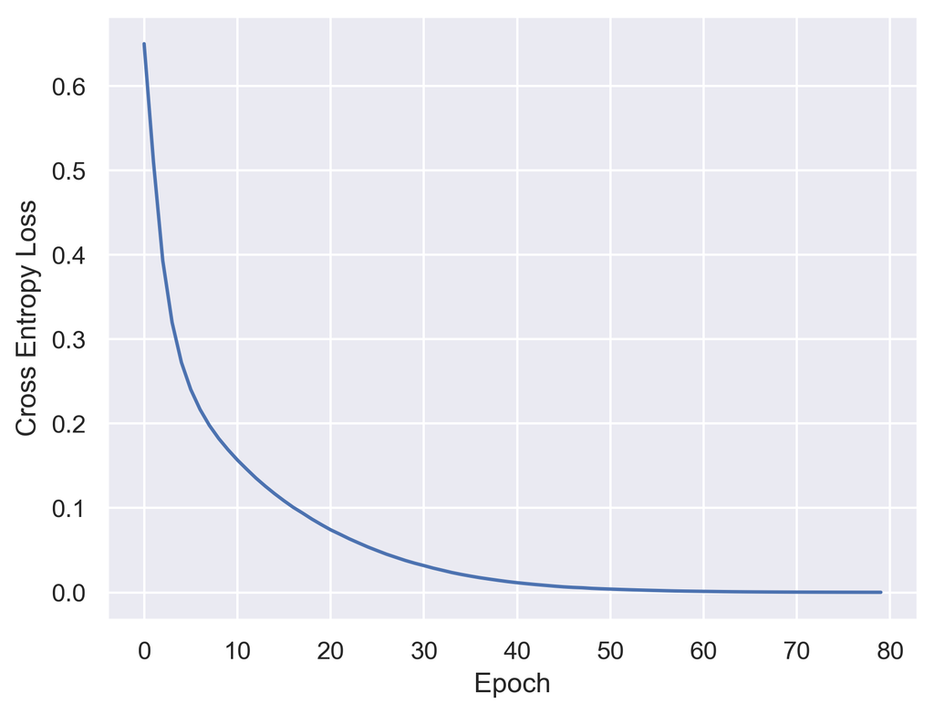

```python
import matplotlib.pyplot as plt
import matplotlib as mpl
import pandas as pd
import seaborn as sns
import os
mpl.rcParams['figure.dpi'] = 300
sns.set()

versions = os.listdir(name)
loss_df = pd.read_csv(name + '/' + versions[-1] + '/metrics.csv')
train_loss = loss_df.loc[~pd.isna(loss_df['train_loss'])]['train_loss']
plt.plot(train_loss);
plt.xlabel('Epoch');
plt.ylabel('Cross Entropy Loss');
```

#### Testing

```python
X_test_counts = count_vect.transform(test_reviews).toarray().astype(float)
test_dataset = TensorDataset(torch.tensor(X_test_counts).to(torch.float32),
                              torch.tensor(test_labels).to(torch.float32))
test_loader = DataLoader(test_dataset, shuffle = False, batch_size = 64)

trainer.test(model_count, dataloaders = test_loader);
```

```
┏━━━━━━━━━━━━━━━━━━━━━━━━━━━┳━━━━━━━━━━━━━━━━━━━━━━━━━━━┓
┃   Runningstage.testing    ┃                           ┃
┃          metric           ┃       DataLoader 0        ┃
┡━━━━━━━━━━━━━━━━━━━━━━━━━━━╇━━━━━━━━━━━━━━━━━━━━━━━━━━━┩
│         test_acc          │    0.8434000015258789     │
│         test_loss         │    1.6720867156982422     │
└───────────────────────────┴───────────────────────────┘
```

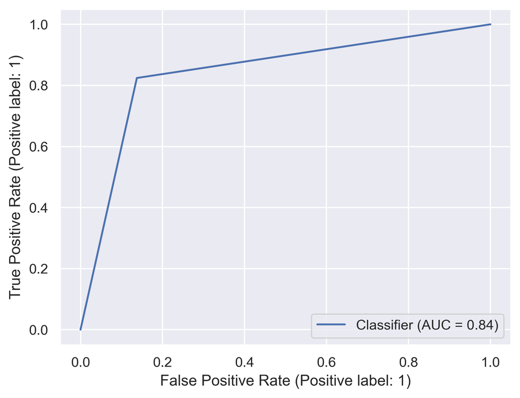

```python
from sklearn.metrics import RocCurveDisplay
model_count.eval()
test_logits = torch.hstack([model_count(x) for x, _ in test_loader])
test_preds = (test_logits > 0).long()
RocCurveDisplay.from_predictions(test_labels, test_preds);
```

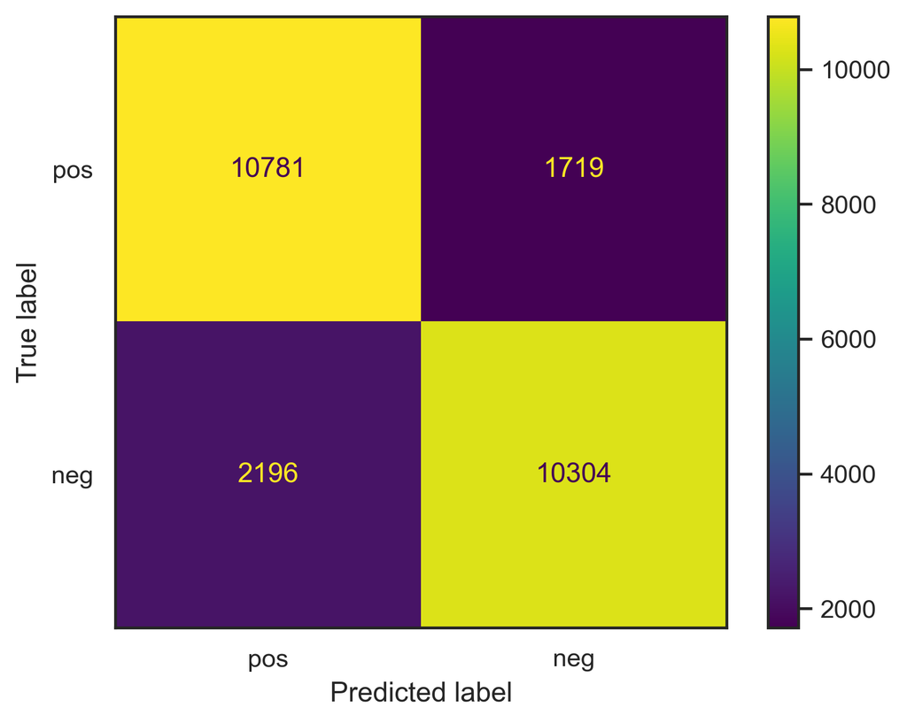

```python
from sklearn.metrics import ConfusionMatrixDisplay
sns.set_theme(style="white", palette=None)
ConfusionMatrixDisplay.from_predictions(
  test_labels.astype(int), test_preds, display_labels = ['pos', 'neg'],
  values_format = '.5g');
```

### Approach II

#### Preprocessing

```python
def get_seq_mat(count_vect, reviews, max_length):
  vocab = count_vect.get_feature_names_out()
  analyze = count_vect.build_analyzer()
  vocab_size = count_vect.max_features

  def find_inv_map(a):
    return np.searchsorted(vocab, a)

  def convert_review_to_idx(review):
    words = np.array(analyze(review))[0:max_length].reshape(-1,1)
    idx = np.apply_along_axis(find_inv_map, axis = 1, arr = words).reshape(-1,)
    idx[idx == vocab_size] = 0
    in_vocab = (vocab[idx] == words[:,0])
    idx[in_vocab] += 1
    idx[~in_vocab] = vocab_size + 1
    n_pad = max(0, max_length - len(words))
    idx = np.concatenate([idx, np.zeros(n_pad)])
    return idx

  seq_mat = np.array([convert_review_to_idx(review) for review in reviews])
  return seq_mat
```

Words that are not in the 10,000-size vocabulary originally created will be set to 10001.

```python
max_length = 256
X_train_seq = get_seq_mat(count_vect, train_reviews, max_length)
X_train_seq[0,:].astype(int)
```

```
array([ 3623,  5927,  8959,  3858,  6111,  7417,  8982,  8742,   598,
        5392,  6234,  5684,  7092,  5308,  3623,  9004,  3818,  4515,
        5927,  9773,  4888, 10001,  4792,   241,  3751,  5620, 10001,
        4792,  7764, 10001,  8961, 10001,  1573,  4792,   466,   173,
        7796,  9693,  3623,   367,  8961, 10001,  4098,  4918,   648,
        6736,  7955,     0,     0,     0,     0,     0,     0,     0,
           0,     0,     0,     0,     0,     0,     0,     0,     0,
           0,     0,     0,     0,     0,     0,     0,     0,     0,
           0,     0,     0,     0,     0,     0,     0,     0,     0,
           0,     0,     0,     0,     0,     0,     0,     0,     0,
           0,     0,     0,     0,     0,     0,     0,     0,     0,
           0,     0,     0,     0,     0,     0,     0,     0,     0,
           0,     0,     0,     0,     0,     0,     0,     0,     0,
           0,     0,     0,     0,     0,     0,     0,     0,     0,
           0,     0,     0,     0,     0,     0,     0,     0,     0,
           0,     0,     0,     0,     0,     0,     0,     0,     0,
           0,     0,     0,     0,     0,     0,     0,     0,     0,
           0,     0,     0,     0,     0,     0,     0,     0,     0,
           0,     0,     0,     0,     0,     0,     0,     0,     0,
           0,     0,     0,     0,     0,     0,     0,     0,     0,
           0,     0,     0,     0,     0,     0,     0,     0,     0,
           0,     0,     0,     0,     0,     0,     0,     0,     0,
           0,     0,     0,     0,     0,     0,     0,     0,     0,
           0,     0,     0,     0,     0,     0,     0,     0,     0,
           0,     0,     0,     0,     0,     0,     0,     0,     0,
           0,     0,     0,     0,     0,     0,     0,     0,     0,
           0,     0,     0,     0,     0,     0,     0,     0,     0,
           0,     0,     0,     0,     0,     0,     0,     0,     0,
           0,     0,     0,     0])
```

#### Architecture and Optimizer

The input data are first fed into an embedding layer, which maps each word in the vocabulary to a vector of length $16$ with output length $16$. The vocabulary has size $10002$; we reserve the $0$ index for padding and $10001$ for unknown words. Thus, the embedding layer will be $10002 \times 16$. Then each review, which has $256$ words, is represented by a $256 \times 16$ matrix.

When the obtain the column mean of that matrix, and each review is now represented by a $16 \times 1$ numerical vector, which is then fed into a hidden layer with $16$ units.

```python
class FeedForwardII(pl.LightningModule):
  def __init__(self, input_dim = 256, hidden_dim = 16,
               vocab_size = 10002, learning_rate = 1e-4):
    super().__init__()
    self.hidden_dim = hidden_dim
    self.input_dim = input_dim
    self.embedding = nn.Embedding(vocab_size, hidden_dim)
    self.layer = nn.Linear(hidden_dim, hidden_dim)
    self.output = nn.Linear(hidden_dim, 1)

    self.learning_rate = learning_rate

  def forward(self, x):
    x = x.long()
    x = self.embedding(x)
    x = x.mean(1)
    x = self.layer(x)
    x = nn.ReLU()(x)
    x = self.output(x)
    x = x.reshape(-1,)
    return x

  def training_step(self, batch, batch_idx):
    x, y = batch
    logits = self.forward(x)
    loss = nn.BCEWithLogitsLoss()(logits, y)
    self.log("train_loss", loss, prog_bar = True, on_epoch = True, on_step = False)
    return loss

  def test_step(self, batch, batch_idx):
    x, y = batch
    logits = self.forward(x)
    loss =  nn.BCEWithLogitsLoss()(logits, y)
    preds = (logits > 0).float()
    self.log("test_loss", loss, prog_bar = True, on_epoch = True, on_step = False)
    acc = ((logits > 0).float() == y).float().mean()
    self.log('test_acc', acc, prog_bar=True, metric_attribute = 'test_accuracy',
             on_epoch = True, on_step = False)
    return loss

  def configure_optimizers(self):
    optimizer = optim.Adam(self.parameters(), lr = self.learning_rate)
    return optimizer
```

#### Training

```python
train_dataset = TensorDataset(torch.tensor(X_train_seq).to(torch.float32),
                              torch.tensor(train_labels).to(torch.float32))
train_loader = DataLoader(train_dataset, shuffle = True, batch_size = 128)

name = "IMDB_seq_logs"
csv_logger = pl_loggers.CSVLogger(name = name, save_dir="")
trainer = Trainer(logger=csv_logger, max_epochs = 100)

model_seq = FeedForwardII()
trainer.fit(model = model_seq, train_dataloaders = train_loader)
```

```
GPU available: False, used: False
TPU available: False, using: 0 TPU cores
IPU available: False, using: 0 IPUs
HPU available: False, using: 0 HPUs

  | Name      | Type      | Params
----------------------------------------
0 | embedding | Embedding | 160 K
1 | layer     | Linear    | 272
2 | output    | Linear    | 17
----------------------------------------
160 K     Trainable params
0         Non-trainable params
160 K     Total params
0.641     Total estimated model params size (MB)
```

```
`Trainer.fit` stopped: `max_epochs=100` reached.
```

[figure not shown]

```python
sns.set()

versions = os.listdir(name)
loss_df = pd.read_csv(name + '/' + versions[-1] + '/metrics.csv')
train_loss = loss_df.loc[~pd.isna(loss_df['train_loss'])]['train_loss']
plt.plot(train_loss);
plt.xlabel('Epoch');
plt.ylabel('Cross Entropy Loss');
```

#### Testing

```python
X_test_seq = get_seq_mat(count_vect, test_reviews, max_length)
test_dataset = TensorDataset(torch.tensor(X_test_seq).to(torch.float32),
                              torch.tensor(test_labels).to(torch.float32))
test_loader = DataLoader(test_dataset, shuffle = False, batch_size = 64)
trainer.test(model_seq, dataloaders = test_loader);
```

```
┏━━━━━━━━━━━━━━━━━━━━━━━━━━━┳━━━━━━━━━━━━━━━━━━━━━━━━━━━┓
┃   Runningstage.testing    ┃                           ┃
┃          metric           ┃       DataLoader 0        ┃
┡━━━━━━━━━━━━━━━━━━━━━━━━━━━╇━━━━━━━━━━━━━━━━━━━━━━━━━━━┩
│         test_acc          │    0.8510800004005432     │
│         test_loss         │    0.3495132029056549     │
└───────────────────────────┴───────────────────────────┘
```

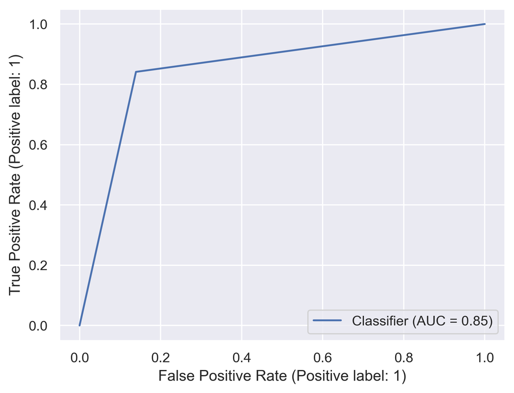

```python
model_seq.eval()
test_logits = torch.hstack([model_seq(x) for x, _ in test_loader])
test_preds = (test_logits > 0).float()

RocCurveDisplay.from_predictions(test_labels, test_preds);
```

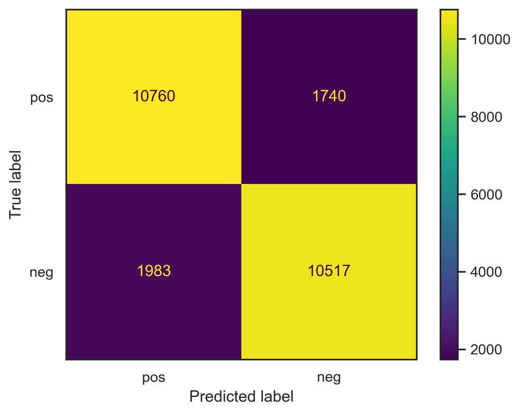

```python
sns.set_theme(style="white", palette=None)
ConfusionMatrixDisplay.from_predictions(
  test_labels, test_preds, display_labels = ['pos', 'neg']);
```